# Telco

> In this project, we are trying to answer **one overarching question**:

> Can we create a model that would be at least **twice as good as a random selection approach** at detecting customers at risk of churn while offering retention programs to less than 50% of customers?

To this end, we plan to create machine learning algorithms that will determine whether a given customer will eventually stop buying our services or not. Applying our models to multiple test cases will help us derive an accuracy score. Please note that a random selection approach is one where Telco would *“randomly*”* select a set quantity of customers to apply its retention program to.

> *Overall, our goal is to develop targeted retention strategies for customers who are likely to churn.*

## 1.3 Preliminary Cleaning Effort

> In the upcoming section, the data is to be cleaned in order to prepare for data analysis, First, we start by deleting the “customerID” column as this column is irrelevant for our purpose (we’re not trying to identify specific customers in our dataset). Following this, we factorize the columns with categorical data.

> After this, we go on to deal with the “TotalCharges” column. This column has some NA values, which we choose to replace by the median value of the column. We use the median value as this is outlier resistent and won’t be influenced by the high/low values in the dataset. Lastly, we also update the Y-value to a numerical basis (Answer “No” will be a 0) to allow for better data analysis.

### 1.3.1 Loading and Cleaning Data

```r
telco$customerID <- NULL

# Factorizing binary variables
telco$Churn <- as.factor(telco$Churn)
telco$PaperlessBilling <- as.factor(telco$PaperlessBilling)
telco$PhoneService <- as.factor(telco$PhoneService)
telco$Dependents <- as.factor(telco$Dependents)
telco$gender <- as.factor(telco$gender)
telco$SeniorCitizen <- as.factor(telco$SeniorCitizen)
telco$Partner <- as.factor(telco$Partner)

# Factorizing non-binary categorical variables
telco$PaymentMethod <- as.factor(telco$PaymentMethod)
telco$Contract <- as.factor(telco$Contract)
telco$InternetService <- as.factor(telco$InternetService)
telco$OnlineSecurity <- as.factor(telco$OnlineSecurity)
telco$OnlineBackup <- as.factor(telco$OnlineBackup)
telco$DeviceProtection <- as.factor(telco$DeviceProtection)
telco$TechSupport <- as.factor(telco$TechSupport)
telco$StreamingTV <- as.factor(telco$StreamingTV)
telco$StreamingMovies <- as.factor(telco$StreamingMovies)
telco$MultipleLines <- as.factor(telco$MultipleLines)

# Handling NA's
telco$TotalCharges[is.na(telco$TotalCharges)]<-median(telco$TotalCharges, na.rm=TRUE)

# Updating Y values
telco$Churn <- ifelse(telco$Churn == "No", 0, 1)

summary(telco)
```

```
##     gender     SeniorCitizen Partner    Dependents     tenure      PhoneService
##  Female:3488   0:5901        No :3641   No :4933   Min.   : 0.00   No : 682
##  Male  :3555   1:1142        Yes:3402   Yes:2110   1st Qu.: 9.00   Yes:6361
##                                                    Median :29.00
##                                                    Mean   :32.37
##                                                    3rd Qu.:55.00
##                                                    Max.   :72.00
##           MultipleLines     InternetService             OnlineSecurity
##  No              :3390   DSL        :2421   No                 :3498
##  No phone service: 682   Fiber optic:3096   No internet service:1526
##  Yes             :2971   No         :1526   Yes                :2019
##
##
##
##               OnlineBackup             DeviceProtection
##  No                 :3088   No                 :3095
##  No internet service:1526   No internet service:1526
##  Yes                :2429   Yes                :2422
##
##
##
##               TechSupport                StreamingTV
##  No                 :3473   No                 :2810
##  No internet service:1526   No internet service:1526
##  Yes                :2044   Yes                :2707
##
##
##
##             StreamingMovies           Contract    PaperlessBilling
##  No                 :2785   Month-to-month:3875   No :2872
##  No internet service:1526   One year      :1473   Yes:4171
##  Yes                :2732   Two year      :1695
##
##
##
##                    PaymentMethod  MonthlyCharges    TotalCharges
##  Bank transfer (automatic):1544   Min.   : 18.25   Min.   :  18.8
##  Credit card (automatic)  :1522   1st Qu.: 35.50   1st Qu.: 402.2
##  Electronic check         :2365   Median : 70.35   Median :1397.5
##  Mailed check             :1612   Mean   : 64.76   Mean   :2281.9
##                                   3rd Qu.: 89.85   3rd Qu.:3786.6
##                                   Max.   :118.75   Max.   :8684.8
##      Churn
##  Min.   :0.0000
##  1st Qu.:0.0000
##  Median :0.0000
##  Mean   :0.2654
##  3rd Qu.:1.0000
##  Max.   :1.0000
```

```r
str(telco)
```

```
## 'data.frame':    7043 obs. of  20 variables:
##  $ gender          : Factor w/ 2 levels "Female","Male": 1 2 2 2 1 1 2 1 1 2 ...
##  $ SeniorCitizen   : Factor w/ 2 levels "0","1": 1 1 1 1 1 1 1 1 1 1 ...
##  $ Partner         : Factor w/ 2 levels "No","Yes": 2 1 1 1 1 1 1 1 2 1 ...
##  $ Dependents      : Factor w/ 2 levels "No","Yes": 1 1 1 1 1 1 2 1 1 2 ...
##  $ tenure          : int  1 34 2 45 2 8 22 10 28 62 ...
##  $ PhoneService    : Factor w/ 2 levels "No","Yes": 1 2 2 1 2 2 2 1 2 2 ...
##  $ MultipleLines   : Factor w/ 3 levels "No","No phone service",..: 2 1 1 2 1 3 3 2 3 1 ...
##  $ InternetService : Factor w/ 3 levels "DSL","Fiber optic",..: 1 1 1 1 2 2 2 1 2 1 ...
##  $ OnlineSecurity  : Factor w/ 3 levels "No","No internet service",..: 1 3 3 3 1 1 1 3 1 3 ...
##  $ OnlineBackup    : Factor w/ 3 levels "No","No internet service",..: 3 1 3 1 1 1 3 1 1 3 ...
##  $ DeviceProtection: Factor w/ 3 levels "No","No internet service",..: 1 3 1 3 1 3 1 1 3 1 ...
##  $ TechSupport     : Factor w/ 3 levels "No","No internet service",..: 1 1 1 3 1 1 1 1 3 1 ...
##  $ StreamingTV     : Factor w/ 3 levels "No","No internet service",..: 1 1 1 1 1 3 3 1 3 1 ...
##  $ StreamingMovies : Factor w/ 3 levels "No","No internet service",..: 1 1 1 1 1 3 1 1 3 1 ...
##  $ Contract        : Factor w/ 3 levels "Month-to-month",..: 1 2 1 2 1 1 1 1 1 2 ...
##  $ PaperlessBilling: Factor w/ 2 levels "No","Yes": 2 1 2 1 2 2 2 1 2 1 ...
##  $ PaymentMethod   : Factor w/ 4 levels "Bank transfer (automatic)",..: 3 4 4 1 3 3 2 4 3 1 ...
##  $ MonthlyCharges  : num  29.9 57 53.9 42.3 70.7 ...
##  $ TotalCharges    : num  29.9 1889.5 108.2 1840.8 151.7 ...
##  $ Churn           : num  0 0 1 0 1 1 0 0 1 0 ...
```

### 1.3.2 Normalization

```r
set.seed(12345)

# Convert all categorical variables into dummies
telco_modelm <- as.data.frame(model.matrix(~., -1, data = telco))
telco_modelm$`(Intercept)` <- NULL

# Normalize the data
normalize <- function(x) {
  return((x-min(x))/(max(x)-min(x)))
}
telco_normal <- as.data.frame(lapply(telco_modelm, normalize))

# Factorize the response variable
telco_normal$Churn <- as.factor(telco_normal$Churn)

# Create a label for our test set
telco_labels <- telco_normal$Churn
```

# 2 First-Level Models

## 2.1 Logistic Regression

### 2.1.1 Simple LR

```r
set.seed(300)
library(caret)

# Customize the tuning process using trainControl() to alter resampling strategy
ctrl <- trainControl(method = "cv", number = 4,
                     selectionFunction = "oneSE")

# Build LR model with the set resampling strategy and grid parameters
lr1 <- train(Churn ~ ., data = telco_normal, method = "glm", metric = "Kappa", trControl = ctrl)
# Show summary of the model
summary(lr1)
```

```
##
## Call:
## NULL
##
## Deviance Residuals:
##     Min       1Q   Median       3Q      Max
## -1.9179  -0.6781  -0.2850   0.7269   3.4255
##
## Coefficients: (7 not defined because of singularities)
##                                       Estimate Std. Error z value Pr(>|z|)
## (Intercept)                           0.420382   0.276656   1.520  0.12863
## genderMale                           -0.021882   0.064794  -0.338  0.73557
## SeniorCitizen1                        0.215077   0.084525   2.545  0.01094 *
## PartnerYes                           -0.002692   0.077788  -0.035  0.97239
## DependentsYes                        -0.153768   0.089712  -1.714  0.08653 .
## tenure                               -4.277426   0.443263  -9.650  < 2e-16 ***
## PhoneServiceYes                       0.179809   0.647908   0.278  0.78138
## MultipleLinesNo.phone.service               NA         NA      NA       NA
## MultipleLinesYes                      0.446911   0.177053   2.524  0.01160 *
## InternetServiceFiber.optic            1.752959   0.797558   2.198  0.02796 *
## InternetServiceNo                    -1.790961   0.806581  -2.220  0.02639 *
## OnlineSecurityNo.internet.service           NA         NA      NA       NA
## OnlineSecurityYes                    -0.205464   0.178626  -1.150  0.25004
## OnlineBackupNo.internet.service             NA         NA      NA       NA
## OnlineBackupYes                       0.025791   0.175215   0.147  0.88298
## DeviceProtectionNo.internet.service         NA         NA      NA       NA
## DeviceProtectionYes                   0.147689   0.176301   0.838  0.40219
## TechSupportNo.internet.service              NA         NA      NA       NA
## TechSupportYes                       -0.178896   0.180452  -0.991  0.32150
## StreamingTVNo.internet.service              NA         NA      NA       NA
## StreamingTVYes                        0.591188   0.326133   1.813  0.06987 .
## StreamingMoviesNo.internet.service          NA         NA      NA       NA
## StreamingMoviesYes                    0.603806   0.326404   1.850  0.06433 .
## ContractOne.year                     -0.667119   0.107468  -6.208 5.38e-10 ***
## ContractTwo.year                     -1.389582   0.175783  -7.905 2.68e-15 ***
## PaperlessBillingYes                   0.341846   0.074468   4.591 4.42e-06 ***
## PaymentMethodCredit.card..automatic. -0.086493   0.114081  -0.758  0.44835
## PaymentMethodElectronic.check         0.305731   0.094484   3.236  0.00121 **
## PaymentMethodMailed.check            -0.056662   0.114849  -0.493  0.62176
## MonthlyCharges                       -4.057371   3.188942  -1.272  0.20326
## TotalCharges                          2.759588   0.607383   4.543 5.54e-06 ***
## ---
## Signif. codes:  0 '***' 0.001 '**' 0.01 '*' 0.05 '.' 0.1 ' ' 1
##
## (Dispersion parameter for binomial family taken to be 1)
##
##     Null deviance: 8150.1  on 7042  degrees of freedom
## Residual deviance: 5829.3  on 7019  degrees of freedom
## AIC: 5877.3
##
## Number of Fisher Scoring iterations: 6
```

```r
# Predict the test set
lr1pred <- predict(lr1, telco_normal[-31])
lm1_cm <- confusionMatrix(data = as.factor(lr1pred), reference = as.factor(telco_labels), positive = "1")

# Show the confusion matrix
lm1_cm
```

```
## Confusion Matrix and Statistics
##
##           Reference
## Prediction    0    1
##          0 4651  834
##          1  523 1035
##
##                Accuracy : 0.8073
##                  95% CI : (0.7979, 0.8165)
##     No Information Rate : 0.7346
##     P-Value [Acc > NIR] : < 2.2e-16
##
##                   Kappa : 0.4781
##
##  Mcnemar's Test P-Value : < 2.2e-16
##
##             Sensitivity : 0.5538
##             Specificity : 0.8989
##          Pos Pred Value : 0.6643
##          Neg Pred Value : 0.8479
##              Prevalence : 0.2654
##          Detection Rate : 0.1470
##    Detection Prevalence : 0.2212
##       Balanced Accuracy : 0.7263
##
##        'Positive' Class : 1
##
```

```r
# Get accuracy and kappa values
lm1_acc <- as.numeric(lm1_cm$overall['Accuracy'])
lm1_kappa <- as.numeric(lm1_cm$overall['Kappa'])
lm1_sens <- as.numeric(lm1_cm$byClass['Sensitivity'])
```

> The initial logistic regression gave us an accuracy score of **0.8073264**, a Kappa value of **0.4780985**, and a sesntivity value of **0.5537721**.

> What immediately stands out in this model is the high number of **false negatives** where our model predicts that a customer would be retained (churn = 0), when it isn’t the case in reality (i.e., they churned; churn = 1). Since this is an initial and relatively simple model, that is okay for now, as we will continue to work with this dataset to improve the prediction accuracy and bring down the false negatives simultaneously. This is the end of our code for the first intermediate submission.

### 2.1.2 Improved LR

```r
set.seed(300)

# Build LR model with the set resampling strategy and grid parameters
lr2 <- train(Churn ~ SeniorCitizen1 + tenure + MultipleLinesYes + InternetServiceFiber.optic + InternetServiceNo + ContractOne.year + ContractTwo.year + PaperlessBillingYes + PaymentMethodElectronic.check + TotalCharges, data = telco_normal, method = "glm", metric = "Kappa", trControl = ctrl)

# Show summary of the model
summary(lr2)
```

```
##
## Call:
## NULL
##
## Deviance Residuals:
##     Min       1Q   Median       3Q      Max
## -1.8108  -0.6951  -0.3005   0.7531   3.4508
##
## Coefficients:
##                               Estimate Std. Error z value Pr(>|z|)
## (Intercept)                   -0.64481    0.08777  -7.346 2.04e-13 ***
## SeniorCitizen1                 0.30975    0.08184   3.785 0.000154 ***
## tenure                        -3.98654    0.41108  -9.698  < 2e-16 ***
## MultipleLinesYes               0.21082    0.07691   2.741 0.006120 **
## InternetServiceFiber.optic     0.75388    0.08778   8.589  < 2e-16 ***
## InternetServiceNo             -0.75896    0.12193  -6.225 4.83e-10 ***
## ContractOne.year              -0.73270    0.10478  -6.993 2.70e-12 ***
## ContractTwo.year              -1.55269    0.17274  -8.989  < 2e-16 ***
## PaperlessBillingYes            0.39013    0.07301   5.343 9.13e-08 ***
## PaymentMethodElectronic.check  0.44593    0.06779   6.578 4.76e-11 ***
## TotalCharges                   2.17980    0.53464   4.077 4.56e-05 ***
## ---
## Signif. codes:  0 '***' 0.001 '**' 0.01 '*' 0.05 '.' 0.1 ' ' 1
##
## (Dispersion parameter for binomial family taken to be 1)
##
##     Null deviance: 8150.1  on 7042  degrees of freedom
## Residual deviance: 5933.9  on 7032  degrees of freedom
## AIC: 5955.9
##
## Number of Fisher Scoring iterations: 6
```

```r
# Predict the test set
lr2pred <- predict(lr2, telco_normal[-31])

lm2_cm <- confusionMatrix(data = as.factor(lr2pred), reference = as.factor(telco_labels), positive = "1")

# Show the confusion matrix
lm2_cm
```

```
## Confusion Matrix and Statistics
##
##           Reference
## Prediction    0    1
##          0 4637  867
##          1  537 1002
##
##                Accuracy : 0.8007
##                  95% CI : (0.7911, 0.8099)
##     No Information Rate : 0.7346
##     P-Value [Acc > NIR] : < 2.2e-16
##
##                   Kappa : 0.4582
##
##  Mcnemar's Test P-Value : < 2.2e-16
##
##             Sensitivity : 0.5361
##             Specificity : 0.8962
##          Pos Pred Value : 0.6511
##          Neg Pred Value : 0.8425
##              Prevalence : 0.2654
##          Detection Rate : 0.1423
##    Detection Prevalence : 0.2185
##       Balanced Accuracy : 0.7162
##
##        'Positive' Class : 1
##
```

```r
# Get accuracy and kappa values
lm2_acc <- as.numeric(lm2_cm$overall['Accuracy'])
lm2_kappa <- as.numeric(lm2_cm$overall['Kappa'])
lm2_sens <- as.numeric(lm2_cm$byClass['Sensitivity'])
```

> The improved logistic regression gave us an accuracy score of **0.8006531**, a Kappa value of **0.4581643**, and a senstivity value of **0.5361156**.

## 2.2 ANN

```r
set.seed(300)

# Set up a grid to test different hidden layers
grid <- expand.grid(size = c(1, 3), decay = c(0, 0.05))

# Build ANN model with the set resampling strategy and grid parameters
ann1 <- caret::train(Churn ~ ., data = telco_normal, method = "nnet", metric = "Kappa", trControl = ctrl, tuneGrid = grid)
# Show summary of the model
summary(ann1)
```

```
## a 30-1-1 network with 33 weights
## options were - entropy fitting  decay=0.05
##   b->h1  i1->h1  i2->h1  i3->h1  i4->h1  i5->h1  i6->h1  i7->h1  i8->h1  i9->h1
##   -0.19    0.01   -0.09    0.00    0.06    2.47   -0.13   -0.04   -0.20   -0.84
## i10->h1 i11->h1 i12->h1 i13->h1 i14->h1 i15->h1 i16->h1 i17->h1 i18->h1 i19->h1
##    0.14    0.13    0.10    0.10   -0.01    0.13   -0.07    0.13    0.08    0.10
## i20->h1 i21->h1 i22->h1 i23->h1 i24->h1 i25->h1 i26->h1 i27->h1 i28->h1 i29->h1
##   -0.27    0.11   -0.27    0.31    0.84   -0.17    0.07   -0.11    0.04    2.05
## i30->h1
##   -1.96
##  b->o h1->o
##  5.01 -9.68
```

```r
# Predict the test set
ann1pred <- predict(ann1, telco_normal[-31])

ann1_cm <- confusionMatrix(data = as.factor(ann1pred), reference = as.factor(telco_labels), positive = "1")

# Show the confusion matrix
ann1_cm
```

```
## Confusion Matrix and Statistics
##
##           Reference
## Prediction    0    1
##          0 4636  817
##          1  538 1052
##
##                Accuracy : 0.8076
##                  95% CI : (0.7982, 0.8168)
##     No Information Rate : 0.7346
##     P-Value [Acc > NIR] : < 2.2e-16
##
##                   Kappa : 0.4819
##
##  Mcnemar's Test P-Value : 4.279e-14
##
##             Sensitivity : 0.5629
##             Specificity : 0.8960
##          Pos Pred Value : 0.6616
##          Neg Pred Value : 0.8502
##              Prevalence : 0.2654
##          Detection Rate : 0.1494
##    Detection Prevalence : 0.2258
##       Balanced Accuracy : 0.7294
##
##        'Positive' Class : 1
##
```

```r
# Get accuracy and kappa values
ann1_acc <- as.numeric(ann1_cm$overall['Accuracy'])
ann1_kappa <- as.numeric(ann1_cm$overall['Kappa'])
ann1_sens <- as.numeric(ann1_cm$byClass['Sensitivity'])
```

> The first ANN model yielded an accuracy score of **0.8076104**, a Kappa value of **0.4818601**, and a sesntivity value of **0.5628678**.

## 2.3 kNN

```r
set.seed(300)

# Use expand.grid() to create grid of tuning parameters
grid <- expand.grid(k = seq(5, 100, 5))

# Build kNN models with the set resampling strategy and grid parameters
knn1 <- train(Churn ~ ., data = telco_normal, method = "knn",
           metric = "Kappa",
           trControl = ctrl,
           tuneGrid = grid)

# Predict the test set
knn1pred <- predict(knn1, telco_normal[-31])

# Create a confusion matrix
knn1_cm <- confusionMatrix(data = as.factor(knn1pred), reference = as.factor(telco_labels), positive = "1")

# Show the confusion matrix
knn1_cm
```

```
## Confusion Matrix and Statistics
##
##           Reference
## Prediction    0    1
##          0 4523  780
##          1  651 1089
##
##                Accuracy : 0.7968
##                  95% CI : (0.7872, 0.8062)
##     No Information Rate : 0.7346
##     P-Value [Acc > NIR] : < 2.2e-16
##
##                   Kappa : 0.4671
##
##  Mcnemar's Test P-Value : 0.0007152
##
##             Sensitivity : 0.5827
##             Specificity : 0.8742
##          Pos Pred Value : 0.6259
##          Neg Pred Value : 0.8529
##              Prevalence : 0.2654
##          Detection Rate : 0.1546
##    Detection Prevalence : 0.2471
##       Balanced Accuracy : 0.7284
##
##        'Positive' Class : 1
##
```

```r
# Get accuracy and kappa values
knn1_acc <- as.numeric(knn1_cm$overall['Accuracy'])
knn1_kappa <- as.numeric(knn1_cm$overall['Kappa'])
knn1_sens <- as.numeric(knn1_cm$byClass['Sensitivity'])
```

> The kNN model gave us an accuracy score of **0.7968195**, a Kappa value of **0.4671409**, and a sesntivity value of **0.5826645**.

## 2.4 Decision Tree

### 2.4.1 Simple DT

```r
set.seed(300)

# Create a simple tuned model with automated parameter tuning of C5.0 decision tree
dt1 <- train(Churn ~ ., data = telco_normal, method = "C5.0")

# Apply the best candidate model to make predictions
dt1_pred <- predict(dt1, telco_normal[-31])

# Create a confusion matrix
dt1_cm <- confusionMatrix(data = as.factor(dt1_pred), reference = as.factor(telco_labels), positive = "1")

# Show the confusion matrix
dt1_cm
```

```
## Confusion Matrix and Statistics
##
##           Reference
## Prediction    0    1
##          0 4808  944
##          1  366  925
##
##                Accuracy : 0.814
##                  95% CI : (0.8047, 0.823)
##     No Information Rate : 0.7346
##     P-Value [Acc > NIR] : < 2.2e-16
##
##                   Kappa : 0.4707
##
##  Mcnemar's Test P-Value : < 2.2e-16
##
##             Sensitivity : 0.4949
##             Specificity : 0.9293
##          Pos Pred Value : 0.7165
##          Neg Pred Value : 0.8359
##              Prevalence : 0.2654
##          Detection Rate : 0.1313
##    Detection Prevalence : 0.1833
##       Balanced Accuracy : 0.7121
##
##        'Positive' Class : 1
##
```

```r
# Get accuracy and kappa values
dt1_acc <- as.numeric(dt1_cm$overall['Accuracy'])
dt1_kappa <- as.numeric(dt1_cm$overall['Kappa'])
dt1_sens <- as.numeric(dt1_cm$byClass['Sensitivity'])
```

> Our in initial Decision Tree model gave us an accuracy score of **0.8139997**, a Kappa value of **0.4706675**, and a sesntivity value of **0.4949171**. We will now try to tune the hyperparameters of the model.

```r
set.seed(300)

# Use expand.grid() to create grid of tuning parameters
grid <- expand.grid(.model = "tree",
                    .trials = c(1, 5, 10, 15, 20, 25, 30),
                    .winnow = "FALSE")

# Customize train() with the control list and grid of parameters
dt2 <- train(Churn ~ ., data = telco_normal, method = "C5.0",
           metric = "Kappa",
           trControl = ctrl,
           tuneGrid = grid)

# Apply the best candidate model to make predictions
dt2_pred <- predict(dt2, telco_normal[-31])

# Create a confusion matrix
dt2_cm <- confusionMatrix(data = as.factor(dt2_pred), reference = as.factor(telco_labels), positive = "1")

dt2_cm
```

```
## Confusion Matrix and Statistics
##
##           Reference
## Prediction    0    1
##          0 4645  819
##          1  529 1050
##
##                Accuracy : 0.8086
##                  95% CI : (0.7992, 0.8177)
##     No Information Rate : 0.7346
##     P-Value [Acc > NIR] : < 2.2e-16
##
##                   Kappa : 0.4835
##
##  Mcnemar's Test P-Value : 3.506e-15
##
##             Sensitivity : 0.5618
##             Specificity : 0.8978
##          Pos Pred Value : 0.6650
##          Neg Pred Value : 0.8501
##              Prevalence : 0.2654
##          Detection Rate : 0.1491
##    Detection Prevalence : 0.2242
##       Balanced Accuracy : 0.7298
##
##        'Positive' Class : 1
##
```

```r
# Get accuracy and kappa values
dt2_acc <- as.numeric(dt2_cm$overall['Accuracy'])
dt2_kappa <- as.numeric(dt2_cm$overall['Kappa'])
dt2_sens <- as.numeric(dt2_cm$byClass['Sensitivity'])
```

> The improved model model saw an accuracy of **0.8086043**, a Kappa value of **0.4835174** and a sensitivity value of **0.5617978**.

## 2.5 Support Vector Machine (SVM)

### 2.5.1 SVM Linear

```r
set.seed(300)

# Customize train() with the control list and grid of parameters
svm1 <- train(Churn ~ ., data = telco_normal, method = "svmLinear",
           metric = "Kappa",
           trControl = ctrl)

# Apply the best candidate model to make predictions
svm1_pred <- predict(svm1, telco_normal[-31])

# Create a confusion matrix
svm1_cm <- confusionMatrix(data = as.factor(svm1_pred), reference = as.factor(telco_labels), positive = "1")

# Show the confusion matrix
svm1_cm
```

```
## Confusion Matrix and Statistics
##
##           Reference
## Prediction    0    1
##          0 4634  864
##          1  540 1005
##
##                Accuracy : 0.8007
##                  95% CI : (0.7911, 0.8099)
##     No Information Rate : 0.7346
##     P-Value [Acc > NIR] : < 2.2e-16
##
##                   Kappa : 0.4588
##
##  Mcnemar's Test P-Value : < 2.2e-16
##
##             Sensitivity : 0.5377
##             Specificity : 0.8956
##          Pos Pred Value : 0.6505
##          Neg Pred Value : 0.8429
##              Prevalence : 0.2654
##          Detection Rate : 0.1427
##    Detection Prevalence : 0.2194
##       Balanced Accuracy : 0.7167
##
##        'Positive' Class : 1
##
```

```r
# Get accuracy and kappa values
svm1_acc <- as.numeric(svm1_cm$overall['Accuracy'])
svm1_kappa <- as.numeric(svm1_cm$overall['Kappa'])
svm1_sens <- as.numeric(svm1_cm$byClass['Sensitivity'])
```

> The SVM model with a linear kernel achieved an accuracy of **0.8006531**, a Kappa value of **0.4587524** and a sensitivity value of **0.5377207**.

### 2.5.2 SVM Radial

```r
set.seed(300)

# Customize train() with the control list and grid of parameters
svm2 <- train(Churn ~ ., data = telco_normal, method = "svmRadial",
           metric = "Kappa",
           trControl = ctrl)

# Apply the best candidate model to make predictions
svm2_pred <- predict(svm2, telco_normal[-31])

# Create a confusion matrix
svm2_cm <- confusionMatrix(data = as.factor(svm2_pred), reference = as.factor(telco_labels), positive = "1")

# Show the confusion matrix
svm2_cm
```

```
## Confusion Matrix and Statistics
##
##           Reference
## Prediction    0    1
##          0 4765  935
##          1  409  934
##
##                Accuracy : 0.8092
##                  95% CI : (0.7998, 0.8183)
##     No Information Rate : 0.7346
##     P-Value [Acc > NIR] : < 2.2e-16
##
##                   Kappa : 0.4622
##
##  Mcnemar's Test P-Value : < 2.2e-16
##
##             Sensitivity : 0.4997
##             Specificity : 0.9210
##          Pos Pred Value : 0.6955
##          Neg Pred Value : 0.8360
##              Prevalence : 0.2654
##          Detection Rate : 0.1326
##    Detection Prevalence : 0.1907
##       Balanced Accuracy : 0.7103
##
##        'Positive' Class : 1
##
```

```r
# Get accuracy and kappa values
svm2_acc <- as.numeric(svm2_cm$overall['Accuracy'])
svm2_kappa <- as.numeric(svm2_cm$overall['Kappa'])
svm2_sens <- as.numeric(svm2_cm$byClass['Sensitivity'])
```

> The SVM model with a radial kernel achieved an accuracy of **0.8091722**, a Kappa value of **0.4622315** and a sensitivity value of **0.4997325**.

### 2.5.3 SVM Poly

```r
set.seed(300)

# Customize train() with the control list and grid of parameters
svm3 <- train(Churn ~ ., data = telco_normal, method = "svmPoly",
           metric = "Kappa",
           trControl = ctrl)

# Apply the best candidate model to make predictions
svm3_pred <- predict(svm3, telco_normal[-31])

# Create a confusion matrix
svm3_cm <- confusionMatrix(data = as.factor(svm3_pred), reference = as.factor(telco_labels), positive = "1")

# Show the confusion matrix
svm3_cm
```

```
## Confusion Matrix and Statistics
##
##           Reference
## Prediction    0    1
##          0 4636  866
##          1  538 1003
##
##                Accuracy : 0.8007
##                  95% CI : (0.7911, 0.8099)
##     No Information Rate : 0.7346
##     P-Value [Acc > NIR] : < 2.2e-16
##
##                   Kappa : 0.4584
##
##  Mcnemar's Test P-Value : < 2.2e-16
##
##             Sensitivity : 0.5367
##             Specificity : 0.8960
##          Pos Pred Value : 0.6509
##          Neg Pred Value : 0.8426
##              Prevalence : 0.2654
##          Detection Rate : 0.1424
##    Detection Prevalence : 0.2188
##       Balanced Accuracy : 0.7163
##
##        'Positive' Class : 1
##
```

```r
# Get accuracy and kappa values
svm3_acc <- as.numeric(svm3_cm$overall['Accuracy'])
svm3_kappa <- as.numeric(svm3_cm$overall['Kappa'])
svm3_sens <- as.numeric(svm3_cm$byClass['Sensitivity'])
```

> The SVM model with a poly kernel achieved an accuracy of **0.8006531**, a Kappa value of **0.4583605** and a sensitivity value of **0.5366506**.

## 2.6 First-Layer Results

```r
# Combine all accuracy, kappa, and sensitivity values
accuracy <- c(lm1_acc, lm2_acc, ann1_acc, knn1_acc, dt1_acc, dt2_acc, svm1_acc, svm2_acc, svm3_acc)
kappa <- c(lm1_kappa, lm2_kappa, ann1_kappa, knn1_kappa, dt1_kappa, dt2_kappa, svm1_kappa, svm2_kappa, svm3_kappa)
sens <- c(lm1_sens, lm2_sens, ann1_sens, knn1_sens, dt1_sens, dt2_sens, svm1_sens, svm2_sens, svm3_sens)

# Create a dataframe with all values
results <- data.frame(accuracy, kappa, sens)
rownames(results) <- c("LR1", "LR2", "ANN1", "kNN1", "DT1", "DT2", "SVM1", "SVM2", "SVM3")
colnames(results) <- c("Accuracy", "Kappa", "Sensitivity")

# Show the created dataframe
results
```

```
##       Accuracy     Kappa Sensitivity
## LR1  0.8073264 0.4780985   0.5537721
## LR2  0.8006531 0.4581643   0.5361156
## ANN1 0.8076104 0.4818601   0.5628678
## kNN1 0.7968195 0.4671409   0.5826645
## DT1  0.8139997 0.4706675   0.4949171
## DT2  0.8086043 0.4835174   0.5617978
## SVM1 0.8006531 0.4587524   0.5377207
## SVM2 0.8091722 0.4622315   0.4997325
## SVM3 0.8006531 0.4583605   0.5366506
```

> With our first-layer results we decide which models we choose for the second-level model. *We make our decision based on the Kappa score for the respective models*.

# 3 Second-Level Model

```r
# Combine everything into one big data frame for our stacked model.
combineddf <- data.frame(lr1pred, ann1pred, knn1pred, dt2_pred, svm2_pred, telco_labels)

# Change colnames to something more intuitive
colnames(combineddf) <- c("LR", "ANN", "kNN", "DT", "SVM", "Actual")

# Show summary statistics for the dataframe
summary(combineddf)
```

```
##  LR       ANN      kNN      DT       SVM      Actual
##  0:5485   0:5453   0:5303   0:5464   0:5700   0:5174
##  1:1558   1:1590   1:1740   1:1579   1:1343   1:1869
```

```r
head(combineddf)
```

```
##   LR ANN kNN DT SVM Actual
## 1  1   1   0  0   1      0
## 2  0   0   0  0   0      0
## 3  0   0   0  0   0      1
## 4  0   0   0  0   0      0
## 5  1   1   1  1   1      1
## 6  1   1   1  1   1      1
```

## 3.1 Simple Stacked Model

```r
set.seed(300)

# Use expand.grid() to create grid of tuning parameters
grid <- expand.grid(.model = "tree",
                    .trials = c(1, 5, 10, 15, 20, 25, 30),
                    .winnow = "FALSE")

# Customize train() with the control list and grid of parameters
dt_comb <- train(Actual ~ ., data = combineddf, method = "C5.0",
           metric = "Kappa",
           trControl = ctrl,
           tuneGrid = grid)

# Apply the best candidate model to make predictions
dt_comb_pred <- predict(dt_comb, combineddf[-6])

# Create a confusion matrix
dt_comb_cm <- confusionMatrix(data = as.factor(dt_comb_pred), reference = as.factor(combineddf$Actual), positive = "1")

# Show the confusion matrix
dt_comb_cm
```

```
## Confusion Matrix and Statistics
##
##           Reference
## Prediction    0    1
##          0 4765  935
##          1  409  934
##
##                Accuracy : 0.8092
##                  95% CI : (0.7998, 0.8183)
##     No Information Rate : 0.7346
##     P-Value [Acc > NIR] : < 2.2e-16
##
##                   Kappa : 0.4622
##
##  Mcnemar's Test P-Value : < 2.2e-16
##
##             Sensitivity : 0.4997
##             Specificity : 0.9210
##          Pos Pred Value : 0.6955
##          Neg Pred Value : 0.8360
##              Prevalence : 0.2654
##          Detection Rate : 0.1326
##    Detection Prevalence : 0.1907
##       Balanced Accuracy : 0.7103
##
##        'Positive' Class : 1
##
```

```r
# Get accuracy and kappa values
dt_comb_acc <- as.numeric(dt_comb_cm$overall['Accuracy'])
dt_comb_kappa <- as.numeric(dt_comb_cm$overall['Kappa'])
dt_comb_sens <- as.numeric(dt_comb_cm$byClass['Sensitivity'])
```

> The combined model achieved an accuracy of **0.8091722**, a Kappa value of **0.4622315**, and a sensitivity score of **0.4997325**.

## 3.2 Results Comparison

```r
# Combine all accuracy, kappa, and sensitivity values
accuracy <- c(lm1_acc, ann1_acc, knn1_acc, dt2_acc, svm2_acc, dt_comb_acc)
kappa <- c(lm1_kappa, ann1_kappa, knn1_kappa, dt2_kappa, svm2_kappa, dt_comb_kappa)
sens <- c(lm1_sens, ann1_sens, knn1_sens, dt2_sens, svm2_sens, dt_comb_sens)

# Create a dataframe with all values
results <- data.frame(accuracy, kappa, sens)
rownames(results) <- c("LR1", "ANN1", "kNN1", "DT2", "SVM2", "Combined")
colnames(results) <- c("Accuracy", "Kappa", "Sensitivity")

# Show the created dataframe
results
```

```
##           Accuracy     Kappa Sensitivity
## LR1      0.8073264 0.4780985   0.5537721
## ANN1     0.8076104 0.4818601   0.5628678
## kNN1     0.7968195 0.4671409   0.5826645
## DT2      0.8086043 0.4835174   0.5617978
## SVM2     0.8091722 0.4622315   0.4997325
## Combined 0.8091722 0.4622315   0.4997325
```

## 3.3 Error Cost Matrix

```r
library(C50)

# Do a 70-30 train-test split
combined_train <- combineddf[1:(nrow(combineddf)*0.7),]
combined_test <- combineddf[((nrow(combineddf)*0.7)+1):nrow(combineddf),]

# Create a cost matrix
error_cost <- matrix(c(0, 1, 4, 0), nrow = 2)

# Apply the cost matrix to the tree
dt2_comb <- C5.0(as.factor(Actual) ~ ., data = combined_train, costs = error_cost)
dt2_comb_pred <- predict(dt2_comb, combined_test)

# Build a confusion matrix
dt2_comb_cm <- confusionMatrix(data = as.factor(dt2_comb_pred), reference = as.factor(combined_test$Actual), positive = "1")

# Show the confusion matrix
dt2_comb_cm
```

```
## Confusion Matrix and Statistics
##
##           Reference
## Prediction    0    1
##          0 1295  200
##          1  237  380
##
##                Accuracy : 0.7931
##                  95% CI : (0.7752, 0.8102)
##     No Information Rate : 0.7254
##     P-Value [Acc > NIR] : 4.397e-13
##
##                   Kappa : 0.4907
##
##  Mcnemar's Test P-Value : 0.08505
##
##             Sensitivity : 0.6552
##             Specificity : 0.8453
##          Pos Pred Value : 0.6159
##          Neg Pred Value : 0.8662
##              Prevalence : 0.2746
##          Detection Rate : 0.1799
##    Detection Prevalence : 0.2921
##       Balanced Accuracy : 0.7502
##
##        'Positive' Class : 1
##
```

```r
# Get accuracy and kappa values
dt2_comb_acc <- as.numeric(dt2_comb_cm$overall['Accuracy'])
dt2_comb_kappa <- as.numeric(dt2_comb_cm$overall['Kappa'])
dt2_comb_sens <- as.numeric(dt2_comb_cm$byClass['Sensitivity'])
```

> By applying an error cost matrix, we can increase our senstivity score to **0.6551724**, but the accuracy rate falls to **0.7930871**, a decrease of **0.0160851**. That is primarily because the decrease in false negatives comes with a corresponding increase in the number of false positives.

As mentioned, the project’s goal is to **identify individuals with a high risk of churn and target them with retention strategies**. Next, we will look into the costs associated with losing customers as well as running such retention strategies. With that information, we will be able to estimate how much money the company will be able to save by targeting only customers who are at risk of churn according to the model.

# 4 Business Implications

## 4.1 Model Results

```r
# Extract numbers from the table
TN <- as.numeric(dt2_comb_cm$table)[1]
FP <- as.numeric(dt2_comb_cm$table)[2]
FN <- as.numeric(dt2_comb_cm$table)[3]
TP <- as.numeric(dt2_comb_cm$table)[4]

# Find the total number of customers in the sample
all_customers <- TP + FN + FP + TN

# Find the number and percentage of customers who are indeed going to churn
customers_at_risk <- TP + FN
customers_at_risk_perc <- customers_at_risk / all_customers

# Find the number and percentage of customers whom our model recommends targeting
customers_targeted <- TP + FP
customers_targeted_perc <- customers_targeted / all_customers

# Find the number of churning customers not identified by the model
missed_churn <- FN

# Find the percentage of identified customers at risk
identified_churn_perc <- TP / customers_at_risk
```

> In our sample of **2112 customers**, **580** people were actually going to churn (27.46% of the sample). Our model recommends offering retention programs to **617** people (29.21%). This number includes **380** customers who are indeed at risk of churn and **237** people who were not going to churn. Although the recommended number of unnecessary retention offerings seems relatively high at first glance, our model allows us to catch and, hopefully, prevent **65.52%** of all churns.

We argue that the expenses associated with running this many retention programs is justified by the prevention of profit losses due to customer churn, and will follow with this rationale. In the next sections, we will extrapolate these results to the entire population from the dataset to calculate the impact of the model.

## 4.2 Assumptions

### 4.2.1 Financial Assumptions

```r
# Calculate the average monthly ARPU as the mean of all monthly charges in the dataset
telco_monthly_arpu <- mean(telco$MonthlyCharges)

# Make a research-informed assumption about Telco's gross margin
telco_gross_profit_margin <- 0.75

# Calculate the average monthly gross profit per user
telco_monthly_gppu <- telco_monthly_arpu * telco_gross_profit_margin

# Make an assumption about the cost of a retention program per user
retention_cost_per_user <- 50
```

The average TTM net profit margin for companies in the telecommunications sector, as of **Q3 2022**, is approximately **12.3%**. Gross profit margins for the sector can run as high as **70% to 80%**, but extremely high overhead expenses erode much of that initial profit balance (“Communications Services Industry Profitability by Quarter, Gross, Operating and Net Margin From Q3 2022”). Assuming a 75% gross profit margin, Telco’s monthly gross profit per user makes up **$48.57**.

### 4.2.2 Lifetime assumptions

In this subsection, we are going to assess the years of loyalty that Telco experiences due to churn (i.e., lost lifespan). This will later be used to compute the lost profit per churn.

```r
# Calculate the average tenure of churned customers
churn_tenure = mean(filter(telco, Churn == 1)$tenure)

# Use the average tenure of loyal customers as a proxy for the total customer lifetime
non_churn_tenure = mean(filter(telco, Churn == 0)$tenure)

# Calculate the lost lifespan of churned customers
lost_lifespan = non_churn_tenure - churn_tenure
```

## 4.3 Profitability Implications

Next, we are going to consider Telco’s profitability in three scenarios: **(1) no retention**, **(2) random retention**, and **(3) model-informed retention**.

### 4.3.1 Scenario 1 - Base Scenario - No Retention

**The first scenario implies not offering any retention programs and allowing organic churn.**

```r
# Calculate the lost profit per churned customer
lost_profit_per_churn <- lost_lifespan * telco_monthly_gppu

# Calculate the total lost profit with no retention strategies
lost_profit_no_retention <- lost_profit_per_churn * nrow(filter(telco, Churn == 1))
```

If we do not offer any retention programs, Telco will lose **$1.7784499^{6}** in foregone profits due to churn.

### 4.3.2 Scenario 2 - Random Retention

**The second scenario implies offering retention programs to a randomly selected sample of 30% of all customers.**

```r
# Calculate the expected percentage of identified churn
randomly_identified_churn_perc <- nrow(filter(telco, Churn == 1))/nrow(telco)

# Assume targeted sample size for random targeting
random_sample_size <- 0.3

# Find number of targeted users
randomly_targeted_users <- round(random_sample_size * nrow(telco))

# Calculate the number of identified customers at risk
random_identified_churn <- round(nrow(telco) * random_sample_size * randomly_identified_churn_perc)

# Create a sensitivity model to find profitability at various retention program success rates
retained_customers_vector <- c()
profits_vector <- c()
success_rates <- seq(0, 1, 0.1)
for (rate in success_rates) {
  retained_customers <- round(random_identified_churn * rate)
  retained_customers_vector <- append(retained_customers_vector, retained_customers)
  regained_profit <- round(retained_customers * lost_profit_per_churn)
  total_retention_costs <- retention_cost_per_user * randomly_targeted_users
  remaining_churn_losses <- (nrow(filter(telco, Churn == 1)) - retained_customers) * lost_profit_per_churn
  bottom_line <- regained_profit - total_retention_costs - lost_profit_no_retention
  profits_vector <- append(profits_vector, bottom_line)
}

# Create and plot a dataframe with sensitivity results
random_sensitivity_df <- data.frame(success_rates, retained_customers_vector, profits_vector)
random_sensitivity_df$relative_profit <- random_sensitivity_df$profits_vector + lost_profit_no_retention
colnames(random_sensitivity_df) <- c("Success Rates", "Retained Customers", "Bottom Line", "P/L Relative to Base Scenario")
random_sensitivity_df
```

```
##    Success Rates Retained Customers Bottom Line P/L Relative to Base Scenario
## 1            0.0                  0    -1884100                       -105650
## 2            0.1                 56    -1830813                        -52363
## 3            0.2                112    -1777526                           924
## 4            0.3                168    -1724239                         54211
## 5            0.4                224    -1670952                        107498
## 6            0.5                280    -1617666                        160784
## 7            0.6                337    -1563427                        215023
## 8            0.7                393    -1510140                        268310
## 9            0.8                449    -1456853                        321597
## 10           0.9                505    -1403566                        374884
## 11           1.0                561    -1350280                        428170
```

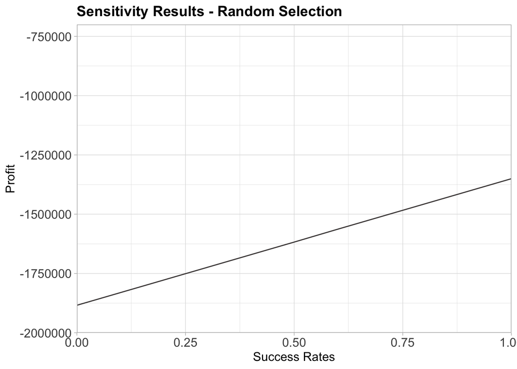

```r
ggplot(random_sensitivity_df, aes(x = success_rates, y = profits_vector)) +
  geom_line(color = "#484444") +
  ggtitle("Sensitivity Results - Random Selection") +
  scale_x_continuous(expand = c(0, 0), limits = c(0, 1)) +
  scale_y_continuous(expand = c(0, 0), limits = c(-2000000, -700000)) +
  xlab("Success Rates") +
  ylab("Profit") +
  theme_light() +
  theme(plot.title = element_text(family = "Arial", face = "bold", size = 14),
        axis.title = element_text(family = "Arial", size = 12),
        axis.text = element_text(family = "Arial", size = 12),
        axis.text.y = element_text(size = 12))
```

In an extreme optimistic sub scenario (100% success rate), randomly offering retention programs to 30% of customers would help Telco retain **561** customers and thus gain **$4.2817^{5}** in profits relative to the base scenario. In an extreme pessimistic scenario (0% success rate), randomly offering retention programs to 30% of customers would help Telco retain **0** customers while also leading to additional losses of **$1.0565^{5}** relative to the base scenario due to retention expenses.

### 4.3.3 Scenario 3 - Model-Informed Retention

**The third scenario implies offering retention programs to all customers who, according to our model, are likely to churn.**

```r
# Find number of targeted users
model_targeted_customers <- round(customers_targeted_perc * nrow(telco))

# Calculate the number of identified customers at risk
model_identified_churn <- round(nrow(filter(telco, Churn == 1)) * identified_churn_perc)

# Create a sensitivity model to find profitability at various retention program success rates
retained_customers_vector <- c()
profits_vector_mi <- c()
success_rates <- seq(0, 1, 0.1)
for (rate in success_rates) {
  retained_customers <- round(model_identified_churn * rate)
  retained_customers_vector <- append(retained_customers_vector, retained_customers)
  regained_profit <- round(retained_customers * lost_profit_per_churn)
  total_retention_costs <- retention_cost_per_user * model_targeted_customers
  bottom_line <- regained_profit - total_retention_costs - lost_profit_no_retention
  profits_vector_mi <- append(profits_vector_mi, bottom_line)
}

# Create and plot a dataframe with sensitivity results
model_sensitivity_df <- data.frame(success_rates, retained_customers_vector, profits_vector_mi)
model_sensitivity_df$relative_profit <- model_sensitivity_df$profits_vector + lost_profit_no_retention
colnames(model_sensitivity_df) <- c("Success Rates", "Retained Customers", "Bottom Line", "P/L Relative to Base Scenario")
model_sensitivity_df
```

```
##    Success Rates Retained Customers Bottom Line P/L Relative to Base Scenario
## 1            0.0                  0  -1881349.9                       -102900
## 2            0.1                122  -1765260.9                         13189
## 3            0.2                245  -1648219.9                        130230
## 4            0.3                368  -1531178.9                        247271
## 5            0.4                490  -1415089.9                        363360
## 6            0.5                612  -1298999.9                        479450
## 7            0.6                735  -1181959.9                        596490
## 8            0.7                858  -1064918.9                        713531
## 9            0.8                980   -948828.9                        829621
## 10           0.9               1102   -832739.9                        945710
## 11           1.0               1225   -715698.9                       1062751
```

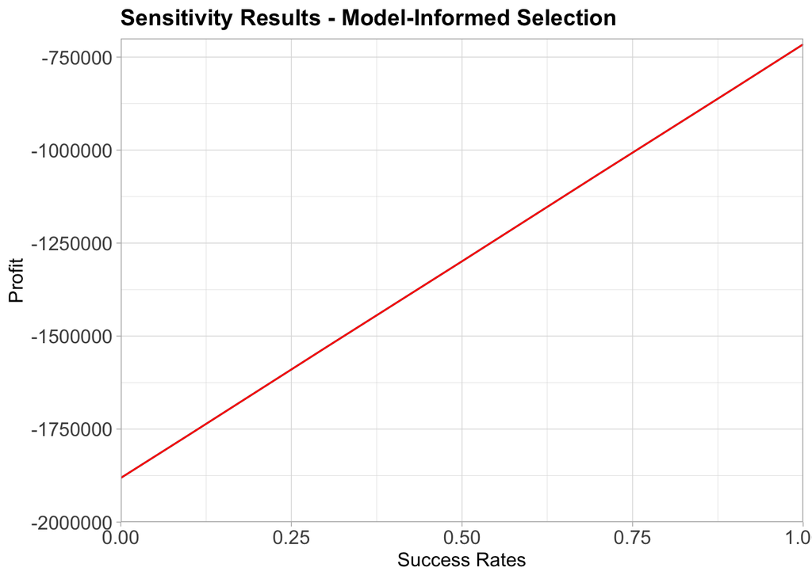

```r
ggplot(model_sensitivity_df, aes(x = success_rates, y = profits_vector_mi)) +
  geom_line() +
  geom_line(color = "red") +
  ggtitle("Sensitivity Results - Model-Informed Selection") +
  scale_x_continuous(expand = c(0, 0), limits = c(0, 1)) +
  scale_y_continuous(expand = c(0, 0), limits = c(-2000000, -700000)) +
  xlab("Success Rates") +
  ylab("Profit") +
  theme_light() +
  theme(plot.title = element_text(family = "Arial", face = "bold", size = 14),
        axis.title = element_text(family = "Arial", size = 12),
        axis.text = element_text(family = "Arial", size = 12),
        axis.text.y = element_text(size = 12))
```

In an extreme optimistic subscenario (100% success rate), following the model’s recommendations would help Telco retain **1225** customers and thus gain **$1.062751^{6}** in profits relative to the base scenario. In an extreme pessimistic subscenario (0% success rate), following the model’s recommendations would help Telco retain **0** customers while also leading to additional losses of **$1.029^{5}** relative to the base scenario due to retention expenses.

### 4.3.4 Visual Purposes - Combining the Plots

[output not shown]

[figure not shown]

```r
library(gganimate)

animation <- data.frame(success_rates, profits_vector, profits_vector_mi) %>%
  ggplot(aes(x = success_rates)) +
  geom_line(aes(y = profits_vector, color = "Random Selection")) +
  geom_line(aes(y = profits_vector_mi, color = "Model Selection")) +
  geom_hline(yintercept = -1 * lost_profit_no_retention, linetype = "F1", color = "#63d1f9") +
  ggtitle("Profitability at Different Retention Program Success Rates") +
  scale_x_continuous(expand = c(0, 0), limits = c(0, 1)) +
  scale_y_continuous(expand = c(0, 0), limits = c(-2000000, -700000)) +
  xlab("Success Rates") +
  ylab("Profit") +
  theme_light() +
  scale_color_manual(values = c("Random Selection" = "#484444", "Model Selection" = "red", "No Retention" = "#63d1f9"), name = "Scenarios") +
  theme(plot.title = element_text(family = "Arial", face = "bold", size = 20),
        axis.title = element_text(family = "Arial", size = 16),
        axis.text = element_text(family = "Arial", size = 16),
        axis.text.y = element_text(size = 16),
        legend.title = element_text(family = "Arial", face = "bold", size = 16),
        legend.text = element_text(family = "Arial", size = 16)) +
  transition_reveal(success_rates)


animate(animation, height = 600, width = 800)
```

```r
anim_save("plot1.gif", animation = last_animation())
```

## 4.4 Conclusion

Overall, the team found that it was indeed possible to indeed obtain better financial results by using a model-informed selection program. Following the presumptions on retention costs and profit margins (see references), even using a random selection model would recoup Telco’s losses given the high cost of churn. Although it is difficult to pinpoint a realistic success rate, the plot above has shown that, with reasonable success rates, having a structured, model-informed retention program in place could improve profits, with a maximum difference of **$1.062751^{6}** in an optimistic scenario. Ideally, the team would like to follow up with Telco to discuss the firm’s specific retention costs, acutal customer tenure, etc., whilst also discussing estimates of program success rates.

# 5 References

- “Communications Services Industry Profitability by Quarter, Gross, Operating and Net Margin From 3 Q 2022.” Communications Services Industry Profitability by Quarter, Gross, Operating and Net Margin From 3 Q 2022, csimarket.com/Industry/industry_Profitability_Ratios.php?ind=905. Accessed 5 Dec. 2022.